# RPlot Oak Trees

Goutham, Shashank, Sujana

November 6, 2018

### 1. Executive Summary

- In this document, team “Morton Arboretum” has analyzed the dataset and developed plots on the Oak Tree Phenology Data Set, for the year 2017. Going forwards, our team will work and provide more insights on the dataset by analyzing the trends.

### 2. Data cleaning on 2017 Dataset

- Read the CSV File into a dataframe
  - Set up the Working Directory
  - Perfrom the Data Cleaning like last time

```r
plotdata = read.csv("plotdata.csv", header = TRUE, stringsAsFactors = FALSE)
```

na.exclude(plotdata)

```r
View(plotdata)
```

```r
plotdata$leaf_breaking_bud_intensity[plotdata$leaf_breaking_bud_intensity == "10-Mar"] <- "03-10"
plotdata$flower_buds_intensity[plotdata$flower_buds_intensity == "10-Mar"] <- "03-10"
plotdata$fruit_intensity[plotdata$fruit_intensity == "10-Mar"] <- "03-10"
plotdata$fruit_drop_intensity[plotdata$fruit_drop_intensity == "10-Mar"] <- "03-10"
plotdata$flower_buds_intensity[plotdata$flower_buds_intensity == "43169.00"] <- "03-10"
plotdata[plotdata == ""] <- "0"
plotdata$leaf_increasing_size_intensity[plotdata$leaf_increasing_size_intensity == "0"] <- "1"
```

Run the below command to get insight onto the data

```r
str(plotdata)
```

```
## 'data.frame':    2874 obs. of  29 variables:
##  $ X.1                           : int  1 2 3 4 5 6 7 8 9 10 ...
##  $ X                             : int  1 2 3 4 5 6 7 8 9 10 ...
##  $ date_observed                 : chr  "3/8/2017" "3/9/2017" "3/9/2017" "3/9/2017" ...
##  $ genus                         : chr  "Acer" "Quercus" "Quercus" "Quercus" ...
##  $ species                       : chr  "x freemanii" "acutissima" "acutissima" "bicolor" ...
##  $ id                            : chr  "321-56*3" "644-33*1" "644-33*1" "135-U*1" ...
##  $ leaf_breaking_bud_observed    : int  0 0 0 0 0 0 0 0 0 0 ...
##  $ leaf_breaking_bud_intensity   : chr  "0" "0" "0" "0" ...
##  $ leaf_observed                 : int  0 0 0 0 0 0 0 0 0 0 ...
##  $ leaf_intensity                : chr  "0" "0" "0" "0" ...
##  $ leaf_increasing_size_observed : int  0 0 0 0 0 0 0 0 0 0 ...
##  $ leaf_increasing_size_intensity: chr  "1" "1" "1" "1" ...
##  $ leaf_color_observed           : int  0 0 0 0 0 0 0 0 0 0 ...
##  $ leaf_color_intensity          : chr  "0" "0" "0" "0" ...
##  $ leaf_falling_observed         : int  0 0 0 0 0 0 0 0 0 0 ...
##  $ flower_buds_observed          : int  1 0 0 0 0 0 0 0 0 1 ...
##  $ flower_buds_intensity         : chr  "11-100" "0" "0" "0" ...
##  $ flower_open_observed          : int  1 0 0 0 0 0 0 0 0 1 ...
##  $ flower_open_intensity         : chr  "0" "0" "0" "0" ...
##  $ fruit_observed                : int  0 0 0 0 0 0 0 0 0 0 ...
##  $ fruit_intensity               : chr  "0" "0" "0" "0" ...
##  $ fruit_ripe_observed           : int  0 0 0 0 0 0 0 0 0 0 ...
##  $ fruit_ripe_intensity          : chr  "0" "0" "0" "0" ...
##  $ fruit_drop_observed           : int  0 0 0 0 0 0 0 0 0 0 ...
##  $ fruit_drop_intensity          : chr  "0" "0" "0" "0" ...
##  $ notes_observer                : chr  "0" "0" "0" "0" ...
##  $ notes_entry                   : chr  "0" "0" "0" "0" ...
##  $ month                         : int  3 3 3 3 3 3 3 3 3 3 ...
##  $ date                          : int  8 9 9 9 9 9 9 9 9 9 ...
```

Import the dplyr library

```r
library(dplyr)
```

### 3. Perform the below steps

```r
deletedata <- select(plotdata, -X.1, -X)
deletedata$leaf_increasing_size_intensity[deletedata$leaf_increasing_size_intensity == "0"] <- as.numeric("1")
deletedata$leaf_increasing_size_intensity[deletedata$leaf_increasing_size_intensity == "5-24%"] <- as.numeric("2")
deletedata$leaf_increasing_size_intensity[deletedata$leaf_increasing_size_intensity == "<25%"] <- as.numeric("2")
deletedata$leaf_increasing_size_intensity[deletedata$leaf_increasing_size_intensity == "25-49%"] <- "3"
deletedata$leaf_increasing_size_intensity[deletedata$leaf_increasing_size_intensity == "25-49"] <- "3"
deletedata$leaf_increasing_size_intensity[deletedata$leaf_increasing_size_intensity == "50-74%"] <- "4"
deletedata$leaf_increasing_size_intensity[deletedata$leaf_increasing_size_intensity == "50-74% "] <- "4"
deletedata$leaf_increasing_size_intensity[deletedata$leaf_increasing_size_intensity == "75-94%"] <- "5"
deletedata$leaf_increasing_size_intensity[deletedata$leaf_increasing_size_intensity == ">95%"] <- "6"
is.character(deletedata$leaf_increasing_size_intensity)
```

```
## [1] TRUE
```

```
* list(deletedata$leaf_increasing_size_intensity)
```

### 4. Plots

- We developed plots to identify the following
  - Leaf Size for all species

#### Plot 1: Size of the leaves filtered by month for all species

```
* Our main agenda in here is to understand how each Oak Tree species respond to the climatic conditions over time. To do that, we wanted to break down all the species based  on the following.

    * Leaves
    * Flower
    * Fruit

* We will have to observe how leaves, flower and fruits of all the species respond to the climate. For this assignment and in this plot, we are going to observe how the leaves of all species respond to the climate over a period of an year.
```

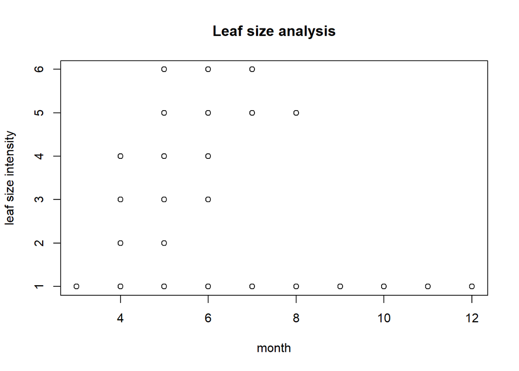

```
* We identified that the leaves of all the species has seen its maximum size between the months 5 and 7.
```

```r
#normalplot for leaf_increasing_size_intensity based on month
#plot(deletedata$leaf_increasing_size_intensity ~ deletedata$month)
plot(deletedata$leaf_increasing_size_intensity ~ deletedata$month,main="Leaf size analysis",xlab="month",ylab="leaf size intensity")
```

#### Plot 2: Size of the leaves filtered by month for species Palustris

```
* Here, we are picking out a specific species to understand how its leaves respond to the climate
```

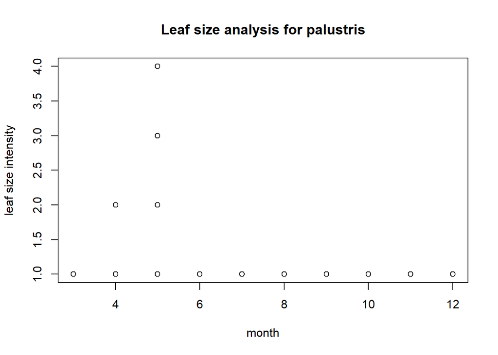

```r
#subsetting and plotting again based on month
palustris_subset <- subset(deletedata, species=="palustris")
#plot(palustris_subset$leaf_increasing_size_intensity ~ palustris_subset$month)
plot(palustris_subset$leaf_increasing_size_intensity ~ palustris_subset$month,main="Leaf size analysis for palustris",xlab="month",ylab="leaf size intensity")
```

#### Plot 3: Size of the leaves filtered by month for species Velutina

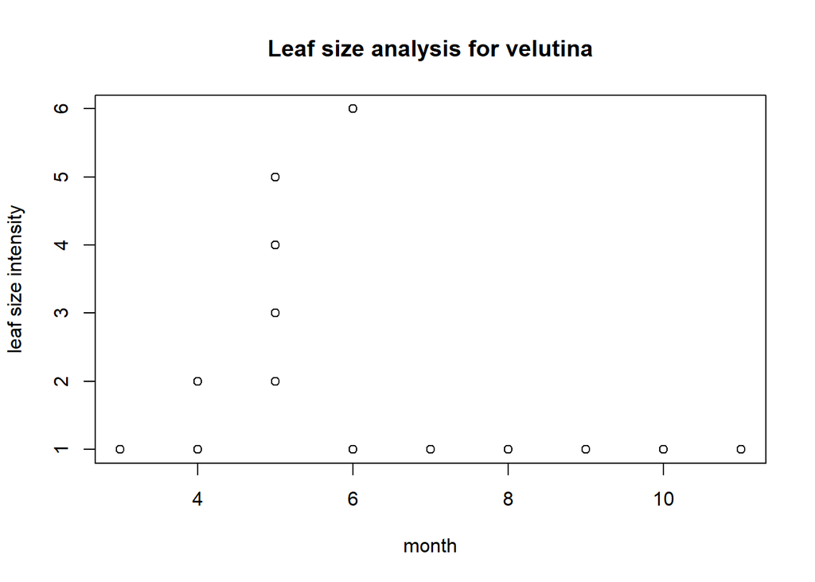

```r
velutina_subset <- subset(deletedata, species=="velutina")
#plot(velutina_subset$leaf_increasing_size_intensity ~ velutina_subset$month)
plot(velutina_subset$leaf_increasing_size_intensity ~ velutina_subset$month,main="Leaf size analysis for velutina",xlab="month",ylab="leaf size intensity")
```

### 5. ggplot2

#### Using ggplot library to plot the same and the results answer our research question 2.

- Research Question: Find out when Leaf size is maximum or minimum for different species throughout the year and what other data corelates with it.
  - Step 1. Prepare the data

```r
#using ggplot
palustris_subset = subset(deletedata, species=="palustris")
alba_subset = subset(deletedata, species=="alba")
rubra_subset_plot = subset(plotdata, species=="rubra")
```

```
* Step 2. Import the library
```

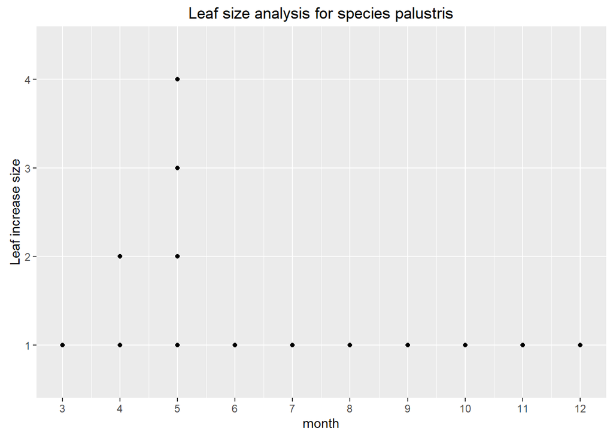

```r
library(ggplot2)
fig = ggplot(palustris_subset, aes(palustris_subset$month, palustris_subset$leaf_increasing_size_intensity
)) +
  geom_point()+
  scale_x_continuous(name = "month", breaks = c(2,3,4,5,6,7,8,9,10,11,12))+
  ylab("Leaf increase size")+
ggtitle("Leaf size analysis for species palustris")

fig
```

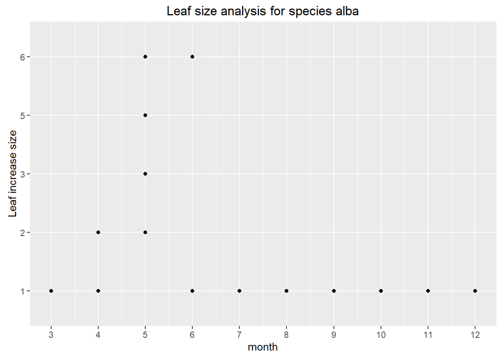

```r
fig0 = ggplot(alba_subset, aes(alba_subset$month, alba_subset$leaf_increasing_size_intensity
)) +
  geom_point()+
  scale_x_continuous(name = "month", breaks = c(2,3,4,5,6,7,8,9,10,11,12))+
  ylab("Leaf increase size")+
  ggtitle("Leaf size analysis for species alba")

fig0
```

### 6. grid extra

[output not shown]

#### Plots for leaf breaking observed, flower breaking observed and Fruit breaking observed versus Months in 2017 specifically for rubra species. This answers the research question number 8 which is “Does the time of budding impact the leafing and flowering time?”.

```
* Plot
```

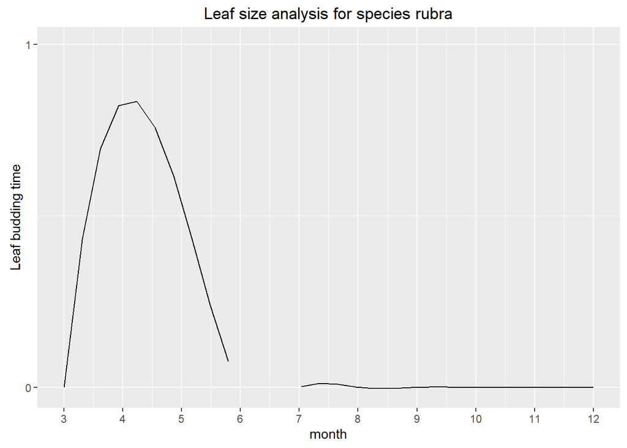

```r
spline_int_rubra_leaf = as.data.frame(spline(rubra_subset_plot$month, rubra_subset_plot$leaf_breaking_bud_observed))
fig1 = ggplot(rubra_subset_plot, aes(rubra_subset_plot$month, rubra_subset_plot$leaf_breaking_bud_observed
)) + geom_line(data = spline_int_rubra_leaf, aes(x=x, y=y))+ scale_x_continuous(name = "month", breaks = c(2,3,4,5,6,7,8,9,10,11,12)) + scale_y_continuous(name = "Leaf budding time", limits = c(-0.01,1), breaks = c(0,1))+
  ggtitle("Leaf size analysis for species rubra")

fig1
```

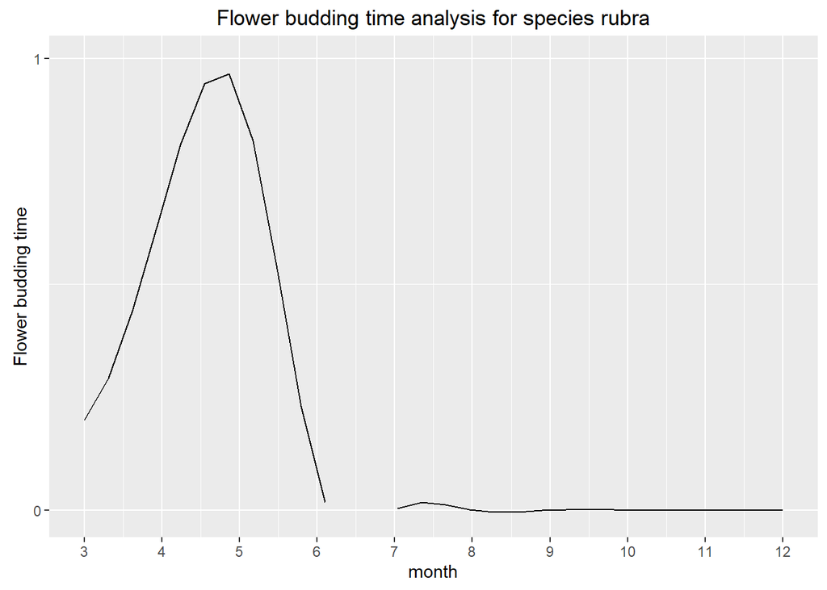

```r
spline_int_rubra = as.data.frame(spline(rubra_subset_plot$month, rubra_subset_plot$flower_buds_observed))
fig2 = ggplot(rubra_subset_plot, aes(rubra_subset_plot$month, rubra_subset_plot$flower_buds_observed
)) + geom_line(data = spline_int_rubra, aes(x=x, y=y))+ scale_x_continuous(name = "month", breaks = c(2,3,4,5,6,7,8,9,10,11,12)) + scale_y_continuous(name = "Flower budding time", limits = c(-0.01,1), breaks = c(0,1))+
  ggtitle("Flower budding time analysis for species rubra")


fig2
```

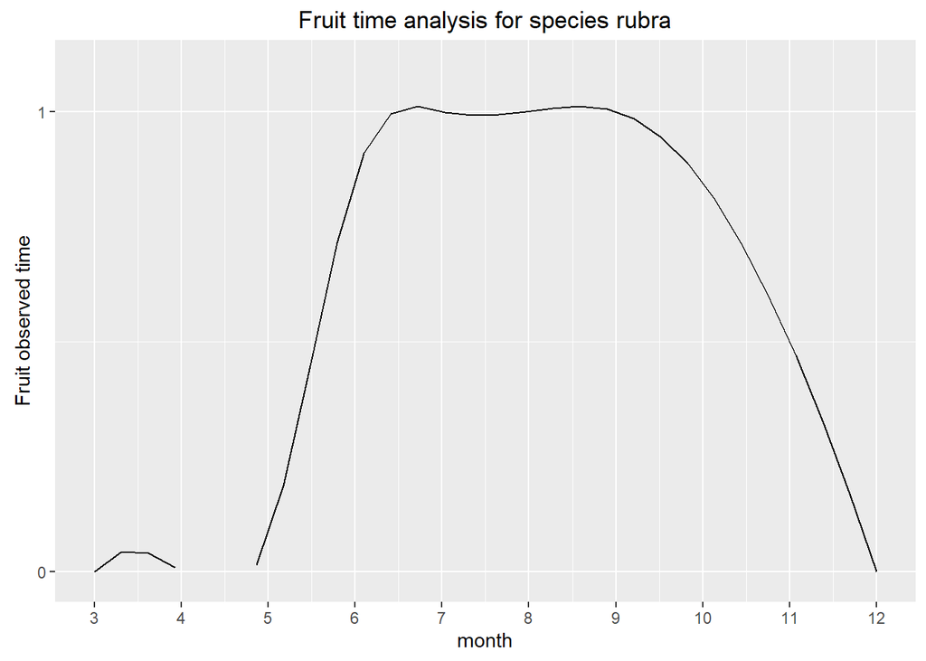

```r
spline_int_rubra_fruit = as.data.frame(spline(rubra_subset_plot$month, rubra_subset_plot$fruit_observed))
fig3 = ggplot(rubra_subset_plot, aes(rubra_subset_plot$month, rubra_subset_plot$fruit_observed
)) + geom_line(data = spline_int_rubra_fruit, aes(x=x, y=y))+ scale_x_continuous(name = "month", breaks = c(2,3,4,5,6,7,8,9,10,11,12)) + scale_y_continuous(name = "Fruit observed time", limits = c(-0.01,1.1), breaks = c(0,1))+
  ggtitle("Fruit time analysis for species rubra")


fig3
```

### 7. Grid Extra Overview

#### This will give an overview all the budding related phenophases during an year for a specific specie.

```r
library(gridExtra)
```

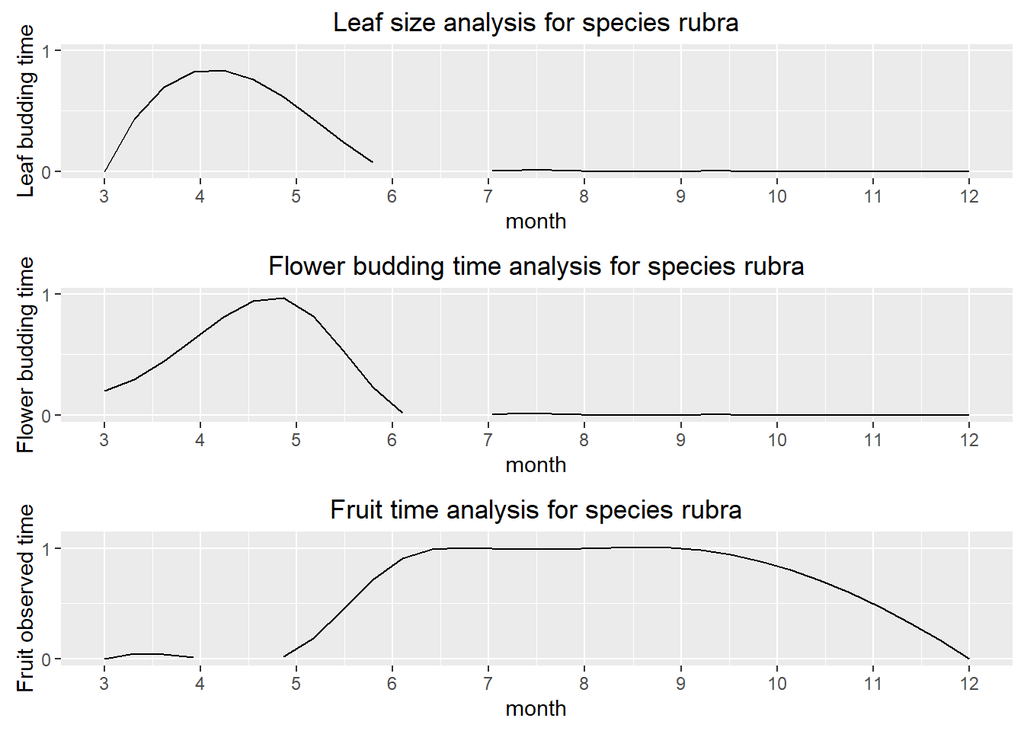

```r
grid.arrange(fig1,fig2,fig3,nrow=3)
```

### 8. Conclusion

In the coming week, our team will work on adding the weather data and developing plots to provide insightful visualizations.

### 9. Contributorship Statement

- Goutham - RMarkdown document, RHTML, Verify the Plots, Push to Git
- Shashank and Sujana - Developed R Plots
- **Proofread** : Everyone